# final-project

https://github.com/lucawperri/STAT-331-Final-Project

```r
library(tidyverse)
library(knitr)
library(gganimate)
library(kableExtra)
library(gifski)
```

## Data Import

```r
co2 <- read_csv("co2_pcap_cons.csv")
sdi <- read_csv("sdi.csv")
```

## Cleaning

```r
# Convert all columns except 'country' to character to avoid type conflicts
co2_clean <- co2 |>
  mutate(across(-country, as.character))

# Pivot CO2 to long
co2_long <- co2_clean |>
  pivot_longer(-country, names_to = "year", values_to = "co2_per_capita") |>
  mutate(
    year = as.integer(year),
    co2_per_capita = parse_number(co2_per_capita)
  )

# Pivot SDI to long
sdi_long <- sdi |>
  pivot_longer(-country, names_to = "year", values_to = "sdi_score") |>
  mutate(
    year = as.integer(year),
    sdi_score = as.numeric(sdi_score)
  )
```

```r
# Join and clean
merged_data <- inner_join(co2_long, sdi_long, by = c("country", "year")) |>
  drop_na(co2_per_capita, sdi_score)

merged_data |>
  slice_head(n = 10) |>
  kable()
```

| country | year | co2_per_capita | sdi_score |
| --- | --- | --- | --- |
| Afghanistan | 1990 | 0.210 | 32.5 |
| Afghanistan | 1991 | 0.183 | 33.1 |
| Afghanistan | 1992 | 0.095 | 34.0 |
| Afghanistan | 1993 | 0.084 | 33.5 |
| Afghanistan | 1994 | 0.075 | 33.0 |
| Afghanistan | 1995 | 0.068 | 35.6 |
| Afghanistan | 1996 | 0.062 | 36.0 |
| Afghanistan | 1997 | 0.056 | 36.6 |
| Afghanistan | 1998 | 0.052 | 37.1 |
| Afghanistan | 1999 | 0.040 | 37.5 |

## Data Visualization

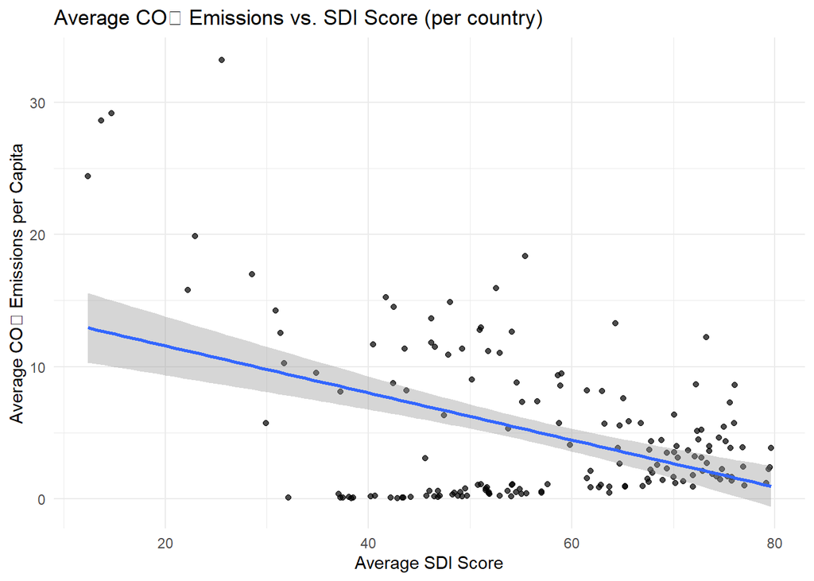

```r
# Aggregate: average per country
avg_data <- merged_data |>
  group_by(country) |>
  summarise(
    avg_sdi = mean(sdi_score, na.rm = TRUE),
    avg_co2 = mean(co2_per_capita, na.rm = TRUE)
  )

# Scatter plot
ggplot(avg_data, aes(x = avg_sdi, y = avg_co2)) +
  geom_point(alpha = 0.7) +
  geom_smooth(method = lm) +
  labs(
    title = "Average CO₂ Emissions vs. SDI Score (per country)",
    x = "Average SDI Score",
    y = "Average CO₂ Emissions per Capita"
  ) +
  theme_minimal()
```

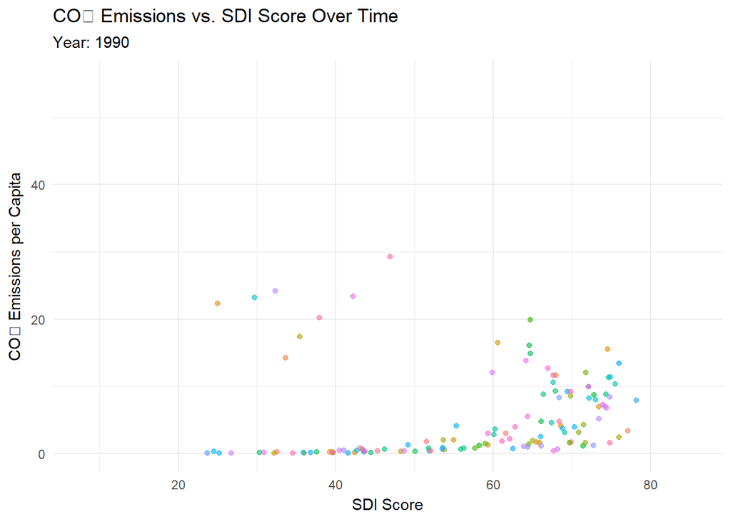

```r
# Animated scatter plot
ggplot(merged_data, aes(x = sdi_score, y = co2_per_capita)) +
  geom_point(aes(color = country), alpha = 0.6, show.legend = FALSE) +
  labs(
    title = "CO₂ Emissions vs. SDI Score Over Time",
    subtitle = "Year: {frame_time}",
    x = "SDI Score",
    y = "CO₂ Emissions per Capita"
  ) +
  transition_time(year) +
  ease_aes('linear') +
  theme_minimal()
```

```r
# Source: https://gganimate.com/
```

## Fitting Linear Regression Model

```r
my_model <- lm(avg_co2 ~ avg_sdi,
               data = avg_data
               )

library(broom)
tidy(my_model) |>
  kable()
```

| term | estimate | std.error | statistic | p.value |
| --- | --- | --- | --- | --- |
| (Intercept) | 15.1448167 | 1.6694848 | 9.071551 | 0 |
| avg_sdi | -0.1782317 | 0.0284985 | -6.254076 | 0 |

estimated linear regression equation:
$$ŷ = 15.14 - 0.18(x)$$

where:

- ŷ = Estimated average C02 emmissions per capita per year over period: 1990-2019
- x = Average SDI score over period: 1990-2019

## Determining Model Fit

```r
# Variance in the response values (actual y values)
response_var <- var(avg_data$avg_co2)

# Variance in the fitted values (predicted y values)
fitted_var <- var(fitted(my_model))

# Variance in the residuals
residual_var <- var(resid(my_model))

# R² = variance in fitted / variance in response
r_squared <- fitted_var / response_var
```

```r
model_fit_table <- tibble(
  Metric = c(
    "Variance in Response (CO₂ per capita)",
    "Variance in Fitted Values",
    "Variance in Residuals",
    "R² (Fitted Variance / Total Response Variance)"
  ),
  Value = c(response_var, fitted_var, residual_var, r_squared)
)

model_fit_table |>
  kable("html", digits = 4, caption = "Model Fit Summary") |>
  kable_styling(full_width = FALSE, bootstrap_options = c("striped", "hover"))
```

Model Fit Summary

| Metric | Value |
| --- | --- |
| Variance in Response (CO₂ per capita) | 36.4398 |
| Variance in Fitted Values | 7.0870 |
| Variance in Residuals | 29.3529 |
| R² (Fitted Variance / Total Response Variance) | 0.1945 |

The variance in the response variable (average CO₂ emissions per capita) was approximately **36.440**, while the variance in the fitted values from the regression model was **7.087**. This means that about **19.45%** of the variability in CO₂ emissions can be explained by a country’s average SDI score from 1990–2019. The remaining **80.55%** is unexplained by this model and may be due to other factors such as industrialization, energy policies, or economic structure. While this suggests that SDI has a modest relationship with CO₂ emissions, it is not a very strong predictor on its own.

## K-Fold Cross Validation

```r
# Define the R² function for one fold
compute_r2 <- function(fold_num, data, folds) {
  validation_idx <- which(folds == fold_num)

  train_data <- data[-validation_idx, ]
  validation_data <- data[validation_idx, ]

  model <- lm(avg_co2 ~ avg_sdi, data = train_data)
  predicted <- predict(model, newdata = validation_data)
  actual <- validation_data$avg_co2

  r2 <- var(predicted) / var(actual)
  return(r2)
}

# Set number of folds
set.seed(42)
k <- 10
folds <- sample(rep(1:k, length.out = nrow(avg_data)))

# Use map to apply function to each fold
r2_values <- map_dbl(1:k, ~compute_r2(.x, avg_data, folds))

# Output vector of R² values
r2_values
```

```
 [1] 0.1090643 0.1368669 0.3100264 0.3906325 0.1748400 0.3132724 0.2218084
 [8] 0.1567636 0.1988303 0.2255776
```

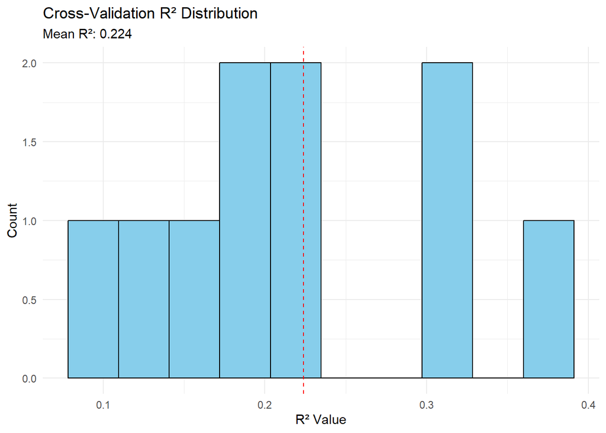

```r
ggplot(data.frame(R2 = r2_values), aes(x = R2)) +
  geom_histogram(bins = 10, fill = "skyblue", color = "black") +
  geom_vline(aes(xintercept = mean(R2)), color = "red", linetype = "dashed") +
  labs(
    title = "Cross-Validation R² Distribution",
    subtitle = paste0("Mean R²: ", round(mean(r2_values), 3)),
    x = "R² Value",
    y = "Count"
  ) +
  theme_minimal()
```

The histogram displays the distribution of R^2 values from 10-fold cross-validation, with a mean of approximately 0.224 (red dashed line). This suggests the model explains about 22.4% of the variance in CO₂ emissions using SDI. The spread of values indicates moderate variability across folds, reflecting limited but consistent predictive power. These results suggest the model captures some underlying relationship but may omit other important predictors.

## Written Report

### Introduction

For our project, we used Gapminder to find our two quantitative variables of our choosing. Those two variables were “CO2 emissions per Capita Consumption based” and the “Sustainable Development Index”. The 1st dataset contains information that tracks how much CO2 “consumption-based emissions generated in the production of goods and services according to where they were consumed, rather than where they were produced” (Our World in Data). The 2nd dataset contains information on the calculation of the development index, which is an efficiency metric made up of 2 other figures known as the “development index” and the “ecological impact index”. This index is to help measure different nations’ efficiency in delivering human development. Meaning how well can a nation maintain its population’s needs while allowing future generations to meet their needs as well. We hypothesize that there is a negative relationship between CO₂ emissions per capita (consumption-based) and the Sustainable Development Index (SDI). Specifically, as SDI score increases, we expect C02 emissions to decrease. The strength of this relationship is expected to be moderate to strong, depending on the country’s economic and environmental policies. The rationale behind this hypothesis is that the Sustainable Development Index penalizes nations for exceeding planetary boundaries, particularly in terms of carbon emissions. Countries that consume more and thus emit more CO₂ per capita are likely to perform worse in sustainability metrics, even if their development index is high. An outside source that supports this hypothesis is the United Nations Development Programme’s 2020 Human Development Report, titled “The Next Frontier: Human Development and the Anthropocene.” This report highlights that human development must now be measured by social progress and the ecological constraints within which development occurs. It stresses that exceeding planetary boundaries—such as carbon budgets—undermines long-term sustainability, a core principle reflected in the SDI.

### Cleaning:

To prepare the data for analysis, we first converted all columns except for the `country` column to character type in the CO₂ dataset. This was done to prevent type mismatches during the pivot operation, as some cells may contain non-numeric characters (e.g., commas or units). We then reshaped both datasets from wide to long format, creating a consistent structure with `country`, `year`, and one quantitative variable per dataset. After reshaping, we parsed the CO₂ data to ensure it was numeric and cast `year` columns to integers. Finally, we merged the datasets by country and year, and removed rows containing `NA` values in either of the two key variables. This may have resulted in the loss of some countries or years from the analysis, potentially biasing our sample toward better-documented regions, but it was necessary to ensure data integrity and allow for a valid comparison between the two metrics.

### Linear Regression Analysis

To explore the relationship between CO₂ emissions per capita and Sustainable Development Index (SDI) scores, we began by aggregating the data for each country across all years from 1990 to 2019. This allowed us to create a single observation per country representing long-term averages of each variable. We then visualized the relationship using a scatterplot, placing SDI on the x-axis and CO₂ emissions on the y-axis. The plot includes a linear regression line with a shaded confidence interval, revealing a modest negative relationship—countries with higher average SDI scores tend to have lower average per capita CO₂ emissions.

We used simple linear regression to quantify this relationship. The statistical model is:

$$\hat{y} = 15.14 - 0.18x$$

where:  
- ( $\hat{y}$ ) is the predicted average CO₂ emissions per capita, and  
- ( x ) is the average SDI score.

The slope of the regression line indicates that for every one-point increase in SDI, a country’s average per capita CO₂ emissions are expected to decrease by approximately 0.18 metric tons, holding all else constant.

To assess model fit, we calculated the variance in the response variable (CO₂), the variance in the model’s fitted values, and the variance in the residuals. These are summarized in the table below. The resulting ( R^2 ) value was approximately **0.1945**, indicating that around **19.45%** of the variability in CO₂ emissions per capita can be explained by differences in SDI. While this suggests a real trend, it also implies that the majority of the variation is likely due to other factors not captured in this model.

### Cross Validation

To assess the generalizability of our model beyond the data used to train it, we implemented 10-fold cross-validation. This method partitions the dataset into 10 roughly equal-sized subsets (or “folds”). For each fold, the model is trained on the remaining nine folds and evaluated on the left out fold. This process is repeated 10 times so that each subset serves as the validation set once. For each iteration, we calculated an R² value to measure how well the model predicted the validation data, using the ratio of the variance in the predicted values to the variance in the actual CO₂ emissions. The distribution of these ten R² values is displayed in the histogram. The mean R² across folds was approximately 0.224, slightly higher than the R² from the full model (0.1945), which suggests no evidence of substantial overfitting. Although performance varied across folds, the R² values remained consistently low to moderate, reinforcing the conclusion that the model captures some, but not all of the factors that explain CO₂ emissions per capita. These results highlight two key insights about our model:

It generalizes reasonably well across different subsets of the data, lending credibility to the relationship between SDI and emissions.

Its predictive power is limited, implying that SDI alone cannot account for the majority of variation in emissions. Future models could be improved by incorporating additional predictors, such as industrialization level, energy source mix, or trade dependence.

Overall, cross-validation supports the initial model findings while providing a more robust estimate of its performance across new data.

### Conclusion

Put simply, our analysis suggests a modest, negative relationship between the average Sustainable Development Index score and average Carbon Dioxide emissions per capita across countries whose data come from the years 1990 to 2019. It should be noted that our data came from a total of 164 countries, and amongst those countries, not every year contained data. Thus, the negative association observed cannot be generalized to all countries as better-documented countries could have an underlying characteristic not present in poorly-documented countries that influences their relationship between their SDI and C02 levels. That said, our conclusion about the 164 countries included still holds substantial weight and our model is solid according to our model validation test. Because we did not run an experiment, we cannot draw a cause-and-effect conclusion. However, since an experiment is next to impossible in this setting, correlational data may be the best foundation for action on this issue. For example, climate action organizations from certain countries, looking at our data analysis, could logically infer that higher CO2 emissions may be causing a lower SDI score and take action to repair the issue. Therefore, our analysis could be the visuospatial, communicative construction that uncovers an impactful truth with endless implications.

### **References**

- Gapminder. *Gapminder Data*. https://www.gapminder.org/data/
- Our World in Data. *CO₂ Emissions per Capita, Consumption-Based*. https://ourworldindata.org/grapher/consumption-co2-per-capita
- United Nations Development Programme. *Human Development Report 2020: The Next Frontier*. https://hdr.undp.org/content/human-development-report-2020